### You would need tensorflow v1.4 and above - ensure you have it

```python
import itertools
import os

import matplotlib.pyplot as plt
import numpy as np
import pandas as pd

from sklearn.preprocessing import LabelBinarizer, LabelEncoder
from sklearn.metrics import confusion_matrix, classification_report
from sklearn.model_selection import train_test_split

from tensorflow import keras
from keras import Model
from keras.layers import Dense, Embedding, LSTM, SpatialDropout1D,Bidirectional,Flatten,Dropout,Input,Conv1D, GlobalMaxPooling1D
from keras.models import Sequential
from keras.layers import Dense, Activation, Dropout
from keras.layers.merge import concatenate
from keras.preprocessing import text, sequence
from keras import utils
%matplotlib inline
```

# Data was scraped using Using Kaggle's public dataset BigQuery integration.

##### The bigquery code used for data scraping.

import bq_helper  
from bq_helper import BigQueryHelper  
from google.cloud import bigquery  
import pandas as pd

stackOverflow = bq_helper.BigQueryHelper(active_project="bigquery-public-data",  
dataset_name="stackoverflow")

bq_assistant = BigQueryHelper("bigquery-public-data", "stackoverflow")  
bq_assistant.list_tables()

query1 = """SELECT id, title, body as post, tags  
FROM `bigquery-public-data.stackoverflow.posts_questions`  
WHERE tags IN ("javascript", "java", "c#", "php", "android", "jquery", "python", "html", "c++", "ios", "css", "mysql", "sql", "asp.net", "ruby-on-rails", "objective-c", "c", ".net", "angularjs", "iphone")  
LIMIT 200000  
"""

df.to_csv('Questions&Tags.csv',index=False)

### Reading the data and seeing contents

```python
os.chdir('/Users/Work/Desktop/Big Data')
df = pd.read_csv("Questions&Tags.csv")
```

```python
df.head()
```

|  | Unnamed: 0 | id | title | post | tags |
| --- | --- | --- | --- | --- | --- |
| 0 | 0 | 26111265 | how to enable the click method after calling e... | <pre><code>$('div.view-more').on('click', func... | jquery |
| 1 | 1 | 954504 | How to get files in a directory, including all... | <p>I'm trying to get a list of all log files (... | python |
| 2 | 2 | 2107283 | how to submit a form and send fields that are ... | <p>I am trying to get a form like this:\n<a hr... | ruby-on-rails |
| 3 | 3 | 27390370 | Python: closest coordinate? | <p>I need help with a function that returns co... | python |
| 4 | 4 | 39742887 | communicate scope values between controllers i... | <ol>\n<li>using getters and setters in service... | angularjs |

```python
df['title']= df['title'].apply(lambda x: " ".join(x.lower() for x in x.split()))
df['title']=df['title'].str.replace('["\n\'?,]'," ")
```

```python
df['title']=df['title'].str.replace('[^0-9a-zA-Z+#-.\s]','')
```

```python
from nltk.corpus import stopwords
stop = stopwords.words('english')
df['title'] = df['title'].apply(lambda x: " ".join(x for x in x.split() if x not in stop))
```

```python
import regex as re
df['title'] = df['title'].str.replace('http\S+|www.\S+', '', case=False)
```

```python
from textblob import Word
df['title'] = df['title'].apply(lambda x: " ".join([Word(word).lemmatize() for word in x.split()]))
```

```python
df.title.head()
```

```
0    enable click method calling e.preventdefault
1       get file directory including subdirectory
2                 submit form send field form tag
3                       python closest coordinate
4    communicate scope value controller angularjs
Name: title, dtype: object
```

```python
#removing '<p>'
df['post']=df['post'].str.strip('<p>')
df['post']=df['post'].str.strip('</p>')
df['post']=df['post'].str.replace('$','')
df['post']= df['post'].apply(lambda x: " ".join(x.lower() for x in x.split()))
df['post']=df['post'].str.replace('["\n\'?,(,)]'," ")
```

```python
df['post']=df['post'].str.replace('[^0-9a-zA-Z+#-.\s]','')
```

```python
from nltk.corpus import stopwords
stop = stopwords.words('english')
df['post'] = df['post'].apply(lambda x: " ".join(x for x in x.split() if x not in stop))
```

```python
import regex as re
df['post'] = df['post'].str.replace('http\S+|www.\S+', '', case=False)
```

```python
from textblob import Word
df['post'] = df['post'].apply(lambda x: " ".join([Word(word).lemmatize() for word in x.split()]))
```

```python
df.post.head()
```

```
0    recode div.view-more .on click function e e.pr...
1    trying get list log file .log directory includ...
2    trying get form like href rel nofollow norefer...
3    need help function return coordinate list coor...
4    ol liusing getters setter service later callin...
Name: post, dtype: object
```

```python
df.tags.value_counts()
```

```
android          25381
javascript       22243
java             20571
php              19950
python           18299
c#               14065
jquery           13611
mysql            12135
c++              12058
c                 7741
angularjs         6177
ruby-on-rails     5802
css               5073
sql               3956
asp.net           3432
iphone            2497
html              2233
ios               2214
objective-c       1973
.net               589
Name: tags, dtype: int64
```

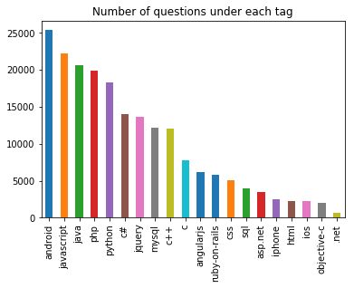

```python
df['tags'].value_counts().sort_values(ascending=False).plot(kind='bar',title='Number of questions under each tag')
```

```python
post = df.post.values
title=df.title.values
y =df.tags.values
```

### Splitting the data into train and test set

```python
train_post = df.post[:12000]
test_post=df.post[12000:]
train_title = df.title[:12000]
test_title=df.title[12000:]
```

```python
tags_train=df.tags[:12000]
tags_test=df.tags[12000:]
```

### Tokenizing the data using the keras tokenizer (using the top used 2000 words)

```python
max_words = 2000
tokenize = text.Tokenizer(num_words=max_words, char_level=False)
```

```python
tokenize.fit_on_texts(df.post) # only fit on train
post_train = tokenize.texts_to_matrix(train_post)
post_test = tokenize.texts_to_matrix(test_post)
```

```python
tokenize.fit_on_texts(df.title) # only fit on train
title_train = tokenize.texts_to_matrix(train_title)
title_test = tokenize.texts_to_matrix(test_title)
```

### Converting the labels to OneHotEncoded form ([0,1,0,0,0,0,0...0,0])

```python
encoder = LabelBinarizer()
encoder.fit(tags_train)
y_train = encoder.transform(tags_train)
y_test = encoder.transform(tags_test)
```

```python
num_classes = len(encoder.classes_)
```

### Printing the training and test input/output shapes

```python
print('post_train shape:', post_train.shape)
print('post_test shape:', post_test.shape)
print('tags_train shape:', y_train.shape)
print('tags_test shape:', y_test.shape)
```

```
post_train shape: (12000, 2000)
post_test shape: (188000, 2000)
tags_train shape: (12000, 20)
tags_test shape: (188000, 20)
```

```python
print('title_train shape:', title_train.shape)
print('title_test shape:', title_test.shape)
print('tags_train shape:', y_train.shape)
print('tags_test shape:', y_test.shape)
```

```
title_train shape: (12000, 2000)
title_test shape: (188000, 2000)
tags_train shape: (12000, 20)
tags_test shape: (188000, 20)
```

### Creating the model

```python
#Setting the batch size and number of epochs
batch_size = 32
epochs = 5
```

```python
#bayes classifier
from sklearn.naive_bayes import MultinomialNB
from sklearn.pipeline import Pipeline
from sklearn.feature_extraction.text import TfidfTransformer
from sklearn.feature_extraction.text import CountVectorizer
from sklearn.metrics import accuracy_score

nb = Pipeline([('vect', CountVectorizer()),
               ('tfidf', TfidfTransformer()),
               ('clf', MultinomialNB()),
              ])
nb.fit(train_post, tags_train)

from sklearn.metrics import classification_report
y_pred = nb.predict(test_post)

print('accuracy %s' % accuracy_score(y_pred, tags_test))
print(classification_report(tags_test, y_pred))
```

```
accuracy 0.5515265957446809
```

```
               precision    recall  f1-score   support

         .net       0.00      0.00      0.00       563
      android       0.48      0.98      0.65     23861
    angularjs       1.00      0.06      0.12      5791
      asp.net       0.00      0.00      0.00      3212
            c       0.98      0.18      0.30      7255
           c#       0.91      0.13      0.22     13250
          c++       0.85      0.53      0.66     11300
          css       0.95      0.04      0.08      4768
         html       0.00      0.00      0.00      2092
          ios       0.00      0.00      0.00      2079
       iphone       0.00      0.00      0.00      2353
         java       0.58      0.75      0.65     19368
   javascript       0.38      0.90      0.54     20920
       jquery       0.70      0.27      0.39     12798
        mysql       0.76      0.47      0.58     11426
  objective-c       0.00      0.00      0.00      1867
          php       0.59      0.78      0.67     18752
       python       0.80      0.80      0.80     17151
ruby-on-rails       1.00      0.01      0.02      5456
          sql       0.00      0.00      0.00      3738

    micro avg       0.55      0.55      0.55    188000
    macro avg       0.50      0.30      0.28    188000
 weighted avg       0.63      0.55      0.48    188000
```

```python
#logistic regresstion.
from sklearn.linear_model import LogisticRegression

logreg = Pipeline([('vect', CountVectorizer()),
                ('tfidf', TfidfTransformer()),
                ('clf', LogisticRegression(n_jobs=1, C=1e5)),
               ])
logreg.fit(np.array(train_post), np.array(tags_train))



y_pred = logreg.predict(np.array(test_post))

print('accuracy %s' % accuracy_score(y_pred, np.array(tags_test)))
print(classification_report(np.array(tags_test), y_pred))
```

```
accuracy 0.7779148936170213
               precision    recall  f1-score   support

         .net       0.45      0.04      0.08       563
      android       0.85      0.92      0.88     23861
    angularjs       0.93      0.88      0.90      5791
      asp.net       0.70      0.59      0.64      3212
            c       0.80      0.74      0.77      7255
           c#       0.67      0.65      0.66     13250
          c++       0.77      0.77      0.77     11300
          css       0.78      0.78      0.78      4768
         html       0.40      0.22      0.29      2092
          ios       0.51      0.30      0.38      2079
       iphone       0.59      0.43      0.50      2353
         java       0.79      0.81      0.80     19368
   javascript       0.75      0.79      0.77     20920
       jquery       0.75      0.79      0.77     12798
        mysql       0.72      0.84      0.78     11426
  objective-c       0.63      0.35      0.45      1867
          php       0.81      0.82      0.82     18752
       python       0.82      0.89      0.86     17151
ruby-on-rails       0.92      0.83      0.87      5456
          sql       0.49      0.25      0.33      3738

    micro avg       0.78      0.78      0.78    188000
    macro avg       0.71      0.64      0.65    188000
 weighted avg       0.77      0.78      0.77    188000
```

### FCFW (post only) with embedding

```python
model_post_emb = Sequential()
model_post_emb.add(Embedding(max_words, 100, input_length=post_train.shape[1]))
model_post_emb.add(SpatialDropout1D(0.7))
model_post_emb.add(Flatten())
model_post_emb.add(Dense(20, activation='softmax'))
model_post_emb.compile(loss='categorical_crossentropy',
              optimizer='adam',
              metrics=['accuracy'])
```

[output not shown]

### FCFW (title only) with embedding

```python
model_title_emb = Sequential()
model_title_emb.add(Embedding(max_words, 100, input_length=title_train.shape[1]))
model_title_emb.add(SpatialDropout1D(0.7))
model_title_emb.add(Flatten())
model_title_emb.add(Dense(20, activation='softmax'))
model_title_emb.compile(loss='categorical_crossentropy',
              optimizer='adam',
              metrics=['accuracy'])
```

### FCFW (Both) with embedding

```python
model_both_post = Input(shape=(post_train.shape[1],))
A1=Embedding(max_words, 100)(model_both_post)
A2=Dense(100, activation='relu')(A1)
model_both_title = Input(shape=(title_train.shape[1],))
B1=Embedding(max_words, 100)(model_both_title)
B2=Dense(100, activation='relu')(B1)
combined1 = concatenate([model_both_post,model_both_title])
dense1=Dense(100, activation='relu')(combined1)
output1= Dense(20, activation='softmax')(dense1)


model_concat_emb=Model(inputs=[model_both_post,model_both_title],outputs=output1)


model_concat_emb.compile(loss='categorical_crossentropy',optimizer='adam',metrics=['accuracy'])
```

### FCFW (post only)

```python
model_post_fcfw = Sequential()
model_post_fcfw.add(Dense(512, input_shape=(max_words,)))
model_post_fcfw.add(Activation('relu'))
model_post_fcfw.add(Dropout(0.5))
model_post_fcfw.add(Dense(num_classes))
model_post_fcfw.add(Activation('softmax'))

model_post_fcfw.compile(loss='categorical_crossentropy',
              optimizer='adam',
              metrics=['accuracy'])
```

### FCFW (title only)

```python
model_title_fcfw = Sequential()
model_title_fcfw.add(Dense(512, input_shape=(max_words,)))
model_title_fcfw.add(Activation('relu'))
model_title_fcfw.add(Dropout(0.5))
model_title_fcfw.add(Dense(num_classes))
model_title_fcfw.add(Activation('softmax'))

model_title_fcfw.compile(loss='categorical_crossentropy',
              optimizer='adam',
              metrics=['accuracy'])
```

### FCFW with both columns

```python
model_both_post_fcfw = Input(shape=(post_train.shape[1],))
A3=Dense(100, activation='relu')(model_both_post_fcfw)
model_both_title_fcfw = Input(shape=(title_train.shape[1],))
B3=Dense(100, activation='relu')(model_both_title_fcfw)
combined2 = concatenate([model_both_post_fcfw,model_both_title_fcfw])
dense2=Dense(100, activation='relu')(combined2)
output2= Dense(20, activation='softmax')(dense2)

model_concat_fcfw=Model(inputs=[model_both_post_fcfw,model_both_title_fcfw],outputs=output2)

model_concat_fcfw.compile(loss='categorical_crossentropy',optimizer='adam',metrics=['accuracy'])
```

### Training the models

```python
history_post_emb=model_post_emb.fit(post_train, y_train,
                    batch_size=batch_size,
                    epochs=epochs,
                    verbose=1,
                    validation_split=0.1)
```

```
WARNING:tensorflow:From /anaconda3/lib/python3.7/site-packages/tensorflow/python/ops/math_ops.py:3066: to_int32 (from tensorflow.python.ops.math_ops) is deprecated and will be removed in a future version.
Instructions for updating:
Use tf.cast instead.
Train on 10800 samples, validate on 1200 samples
```

```python
history_title_emb=model_title_emb.fit(title_train, y_train,
                    batch_size=batch_size,
                    epochs=epochs,
                    verbose=1,
                    validation_split=0.1)
```

```
Train on 10800 samples, validate on 1200 samples
```

```python
history_concat_emb=model_concat_emb.fit([post_train,title_train], y_train,
                    batch_size=batch_size,
                    epochs=epochs,
                    verbose=1,
                    validation_split=0.1)
```

```
Train on 10800 samples, validate on 1200 samples
```

```python
history_post_fcfw = model_post_fcfw.fit(post_train, y_train,
                    batch_size=batch_size,
                    epochs=epochs,
                    verbose=1,
                    validation_split=0.1)
```

```
Train on 10800 samples, validate on 1200 samples
```

```python
history_title_fcfw=model_title_fcfw.fit(title_train, y_train,
                    batch_size=batch_size,
                    epochs=epochs,
                    verbose=1,
                    validation_split=0.1)
```

```
Train on 10800 samples, validate on 1200 samples
```

```python
history_concat_fcfw = model_concat_fcfw.fit([post_train,title_train], y_train,
                    batch_size=batch_size,
                    epochs=epochs,
                    verbose=1,
                    validation_split=0.1)
```

```
Train on 10800 samples, validate on 1200 samples
```

### Evaluating on the test set

```python
score_post_emb = model_post_emb.evaluate(post_test, y_test,
                       batch_size=batch_size, verbose=1)
print('Test score:', score_post_emb[0])
print('Test accuracy:', score_post_emb[1]*100)
```

```
Test score: 1.0792391638273888
Test accuracy: 75.97978723404255
```

```python
score_title_emb = model_title_emb.evaluate(title_test, y_test,
                       batch_size=batch_size, verbose=1)
print('Test score:', score_title_emb[0])
print('Test accuracy:', score_title_emb[1]*100)
```

```
Test score: 1.4113664571630193
Test accuracy: 62.17446808510638
```

```python
score_emb_both = model_concat_emb.evaluate([post_test,title_test], y_test,
                       batch_size=batch_size, verbose=1)
print('Test score:', score_emb_both[0])
print('Test accuracy:', score_emb_both[1]*100)
```

```
Test score: 0.5130653875606491
Test accuracy: 85.03510638297873
```

```python
score_post_fcfw = model_post_fcfw.evaluate(post_test, y_test,
                       batch_size=batch_size, verbose=1)
print('Test score:', score_post_fcfw[0])
print('Test accuracy:', score_post_fcfw[1]*100)
```

```
Test score: 0.7652912517075843
Test accuracy: 78.72606382978724
```

```python
score_title_fcfw = model_title_fcfw.evaluate(title_test, y_test,
                       batch_size=batch_size, verbose=1)
print('Test score:', score_title_fcfw[0])
print('Test accuracy:', score_title_fcfw[1]*100)
```

```
Test score: 1.1855096699430587
Test accuracy: 64.40797872340426
```

```python
score_fcfw_both = model_concat_fcfw.evaluate([post_test,title_test], y_test,
                       batch_size=batch_size, verbose=1)
print('Test score:', score_fcfw_both[0])
print('Test accuracy:', score_fcfw_both[1]*100)
```

```
Test score: 0.5145785705339402
Test accuracy: 84.98989361702127
```

```python
text_labels = encoder.classes_
tags_test=np.array(tags_test)
x_test_title=np.array(title_test)
x_test_post=np.array(post_test)
test_post=np.array(test_post)
test_title=np.array(test_title)
for i in range(10):
    pred=model_concat_fcfw.predict([x_test_post,x_test_title])
    print('Title: '+test_title[i][:50],"...")
    print('Post: '+test_post[i][:50],"...")
    print('Actual label:'+tags_test[i])
    print("Predicted label:"+text_labels[np.argmax(pred[i])]+"\n")
```

[output not shown]

```python
y_softmax = model_concat_fcfw.predict([x_test_post,x_test_title])

y_test_1d = []
y_pred_1d = []

for i in range(len(y_test)):
    probs = y_test[i]
    index_arr = np.nonzero(probs)
    one_hot_index = index_arr[0].item(0)
    y_test_1d.append(one_hot_index)

for i in range(0, len(y_softmax)):
    probs = y_softmax[i]
    predicted_index = np.argmax(probs)
    y_pred_1d.append(predicted_index)
```

### Generate classification report

```python
print(classification_report(y_test_1d, y_pred_1d, target_names=encoder.classes_))
```

```
               precision    recall  f1-score   support

         .net       0.70      0.09      0.15       563
      android       0.92      0.94      0.93     23861
    angularjs       0.98      0.93      0.96      5791
      asp.net       0.76      0.70      0.73      3212
            c       0.74      0.80      0.77      7255
           c#       0.71      0.75      0.73     13250
          c++       0.80      0.79      0.79     11300
          css       0.84      0.89      0.86      4768
         html       0.54      0.54      0.54      2092
          ios       0.65      0.48      0.55      2079
       iphone       0.62      0.60      0.61      2353
         java       0.86      0.88      0.87     19368
   javascript       0.83      0.88      0.85     20920
       jquery       0.88      0.87      0.87     12798
        mysql       0.86      0.88      0.87     11426
  objective-c       0.71      0.45      0.55      1867
          php       0.91      0.88      0.90     18752
       python       0.94      0.93      0.94     17151
ruby-on-rails       0.96      0.90      0.93      5456
          sql       0.70      0.62      0.66      3738

    micro avg       0.85      0.85      0.85    188000
    macro avg       0.79      0.74      0.75    188000
 weighted avg       0.85      0.85      0.85    188000
```

### Generate confusion matrix acoss data - this code is from the scikit-learn help pages

```python
def plot_confusion_matrix(cm, classes,
                          title='Confusion matrix',
                          cmap=plt.cm.Blues):
    """
    This function prints and plots the confusion matrix.
    Normalization can be applied by setting `normalize=True`.
    """

    cm = cm.astype('float') / cm.sum(axis=1)[:, np.newaxis]

    plt.imshow(cm, interpolation='nearest', cmap=cmap)
    plt.title(title, fontsize=30)
    plt.colorbar()
    tick_marks = np.arange(len(classes))
    plt.xticks(tick_marks, classes, rotation=45, fontsize=22)
    plt.yticks(tick_marks, classes, fontsize=22)

    fmt = '.2f'
    thresh = cm.max() / 2.
    for i, j in itertools.product(range(cm.shape[0]), range(cm.shape[1])):
        plt.text(j, i, format(cm[i, j], fmt),
                 horizontalalignment="center",
                 color="white" if cm[i, j] > thresh else "black")

    plt.ylabel('True label', fontsize=25)
    plt.xlabel('Predicted label', fontsize=25)
```

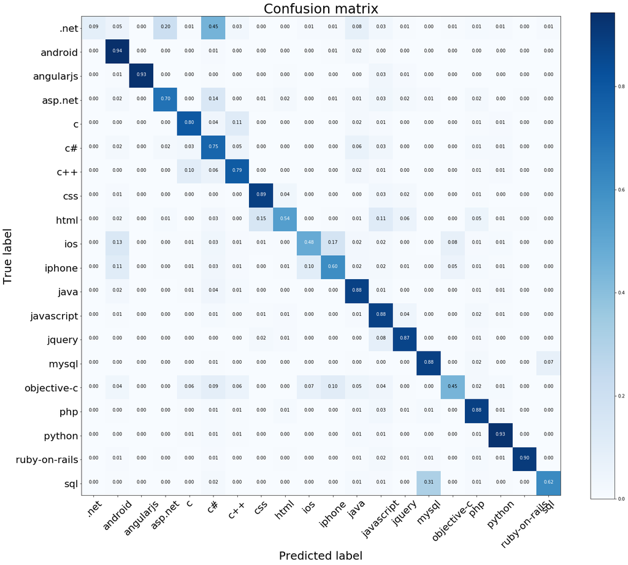

```python
cnf_matrix = confusion_matrix(y_test_1d, y_pred_1d)
plt.figure(figsize=(24,20))
plot_confusion_matrix(cnf_matrix, classes=text_labels, title="Confusion matrix")
plt.show()
```